# White Wine Analysis by David DeSimone

```
##    Min. 1st Qu.  Median    Mean 3rd Qu.    Max.
##  0.0000  0.2700  0.3200  0.3342  0.3900  1.6600
```

Citric acid follows a normal distribution pattern. There is an interesting bump of occurrences at ~ .7 before sharply tailing off.

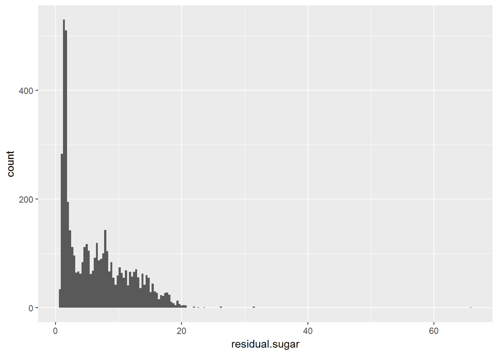

I can see the residual sugar distribution is skewed to the right and there are some outliers far to the right.

```
##
##  0.6  0.7  0.8  0.9 0.95    1
##    2    7   25   39    4   93
```

```
##
##    22  22.6  23.5 26.05  31.6  65.8
##     2     1     1     2     2     1
```

I can see there are only a few instances of sugar above 22 and just one outlier above the readings in the low 30’s, at 65.8.

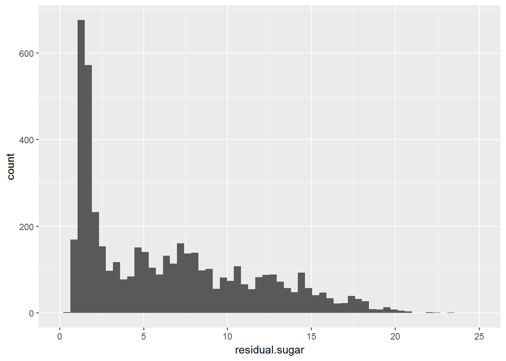

I’ve cut off some of the outliers to get a better look at the data.

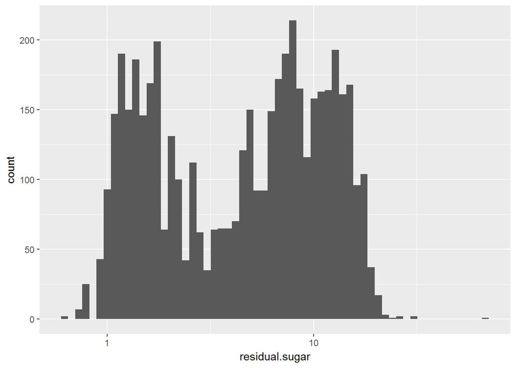

Looking at this same data log scaled, the data has more of a bimodal or even trimodal distribution with a concentration around 1.5 and concentrations at 8, 12.

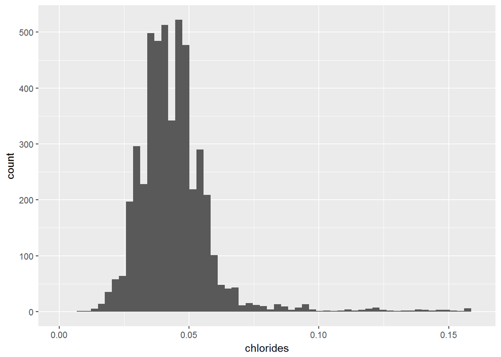